# Checkpoint 5

Katya Kelly & Katja McKiernan

November 29, 2017

We both worked equally on finding questions, building the models, researching models and priors, and pair programming. /

```r
cleanQuakes = read.csv("cleanQuakes.csv")

library(dplyr)
cleanQuakes1 <- cleanQuakes %>%
  select(-c(X.1))
```

```r
library(stringr)
library(lubridate)
#Creating a year, month, and day columns and adding to cleanQuakes1
Year_ <- year(cleanQuakes1$time)
Month_ <- month(cleanQuakes1$time)
Day_ <- day(cleanQuakes1$time)
cleanQuakes1 <- cbind(cleanQuakes1, Year_)
cleanQuakes1 <- cbind(cleanQuakes1, Month_)
cleanQuakes1 <- cbind(cleanQuakes1, Day_)

#lapply(cleanQuakes1$time, as.character)

cleanQuakes1$time <- substring(cleanQuakes1$time, 1, 19)
time_of_Quake <- str_sub(cleanQuakes1$time, -8,-1)
cleanQuakes1 <- cbind(cleanQuakes1, time_of_Quake)

cleanQuakesFin <- cleanQuakes1 %>%
  select(-c(time))
```

```r
library(dplyr)
quakesAbove7 <- filter(cleanQuakesFin, mag >= 7)
quakesSince1950 <- filter(cleanQuakesFin, Year_ >= 1950)
quakesAbove7Since1950 <- filter(cleanQuakesFin, Year_ >=1950, mag >= 7)
```

### Question: Can we predict the yearly rate of large earthquakes (above magnitude 7) and determine whether 8 large earthquakes in the year 1957 was significant?

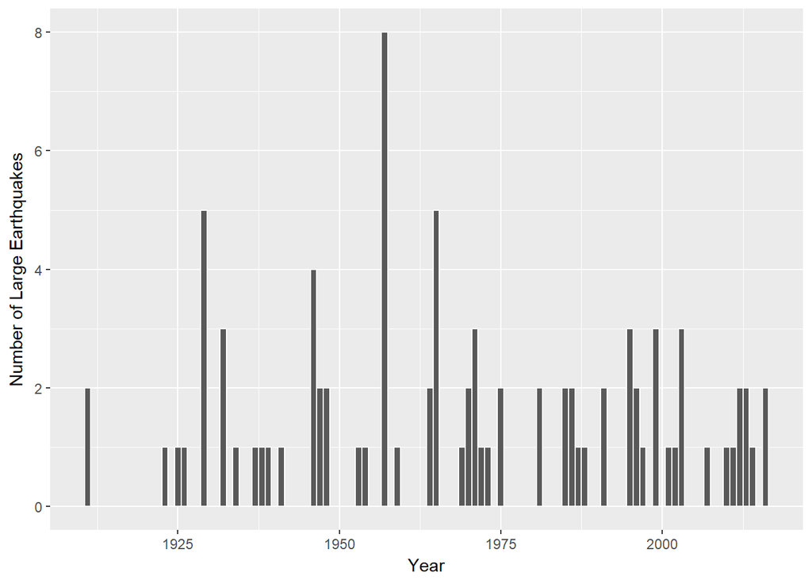

```r
library(ggplot2)
# Frequency of large earthquakes per year
ggplot(data=quakesAbove7, aes(x = Year_)) + geom_histogram(binwidth = 1, color="white") +
  xlab("Year") + ylab("Number of Large Earthquakes")
```

```r
# Number of large earthquakes in 1957 (8) - unusually high or not?
sum(cleanQuakesFin$Year_ == 1957 & cleanQuakesFin$mag >= 7)
```

```
## [1] 8
```

Notation: $\lambda$ = rate of large earthquakes (number/year)
$X_i$ = longitude of earthquake $i$
$Y_i$ = latitude of earthquake $i$
$N$ = total number of large earthquakes from 1900-2017 in North America
Models:
Model 1:
$$N|\lambda \sim Pois(sqrt((X_i)^2)\lambda)$$
$$\lambda \sim Gamma(1,2)$$
Model 2:
$$N|\lambda \sim Pois(sqrt((Y_i)^2\lambda)$$
$$\lambda \sim Gamma(1,2)$$
Model 3:
$$N|\lambda \sim Pois(sqrt((X_i + Y_i)^2)\lambda)$$
$$\lambda \sim Gamma(1,2)$$

```r
library(rjags)
rate_long_model <- "model{
  #Data
    #Note: dnorm in rjags takes the precision, not st. dev.

  N ~ dpois(mu)
  for (i in 1:length(N)) {
    mu = (sqrt((X[i])^2))*lambda
  }



  #Priors

  lambda ~ dgamma(1,2)

}"

#set up an algorithm to simulate the posterior by
#combining the model (nfl_model) and data (sports)
#set the random number seed
rate_long_jags <- jags.model(textConnection(rate_long_model),
                        data = list(N=nrow(quakesAbove7), X=quakesAbove7$longitude),
                        inits = list(.RNG.name = "base::Wichmann-Hill", .RNG.seed = 1989))
#simulate a sample from the posterior
rate_long_sim <- coda.samples(rate_long_jags,
                        variable.names = c("lambda"), n.iter=10000)

#store the samples in a data frame:
rate_long_samples <- data.frame(steps=c(1:10000), rate_long_sim[[1]])
head(rate_long_samples)
```

```
##   steps    lambda
## 1     1 0.5843355
## 2     2 0.5966177
## 3     3 0.5200456
## 4     4 0.4536903
## 5     5 0.5825567
## 6     6 0.5281935
```

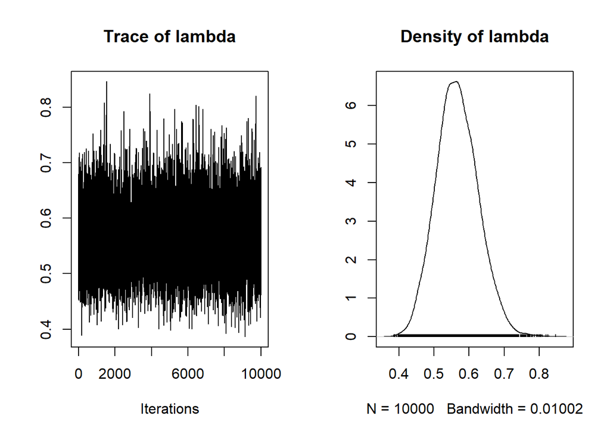

```r
plot(rate_long_sim)
```

```r
summary(rate_long_sim)
```

```
##
## Iterations = 1:10000
## Thinning interval = 1
## Number of chains = 1
## Sample size per chain = 10000
##
## 1. Empirical mean and standard deviation for each variable,
##    plus standard error of the mean:
##
##           Mean             SD       Naive SE Time-series SE
##      0.5665185      0.0596529      0.0005965      0.0005738
##
## 2. Quantiles for each variable:
##
##   2.5%    25%    50%    75%  97.5%
## 0.4561 0.5257 0.5643 0.6058 0.6881
```

Based on just longitude, our model predicts there to be about 0.57 earthquakes per year on average. This is slightly fewer than our joint model that uses both latitude and longitude, and significantly fewer than our model with just latitude.

```r
rate_lat_model <- "model{
  #Data
    #Note: dnorm in rjags takes the precision, not st. dev.

  N ~ dpois(mu)
  for (i in 1:length(N)) {
    mu = sqrt(Y[i]^2)*lambda
  }



  #Priors

  lambda ~ dgamma(1,2)

}"

#set up an algorithm to simulate the posterior by
#combining the model (nfl_model) and data (sports)
#set the random number seed
rate_lat_jags <- jags.model(textConnection(rate_lat_model),
                        data = list(N=nrow(quakesAbove7), Y=quakesAbove7$latitude),
                        inits = list(.RNG.name = "base::Wichmann-Hill", .RNG.seed = 1989))
#simulate a sample from the posterior
rate_lat_sim <- coda.samples(rate_lat_jags,
                        variable.names = c("lambda"), n.iter=10000)

#store the samples in a data frame:
rate_lat_samples <- data.frame(steps=c(1:10000), rate_lat_sim[[1]])
head(rate_lat_samples)
```

```
##   steps   lambda
## 1     1 4.300867
## 2     2 4.391267
## 3     3 3.827676
## 4     4 3.339283
## 5     5 4.287774
## 6     6 3.887646
```

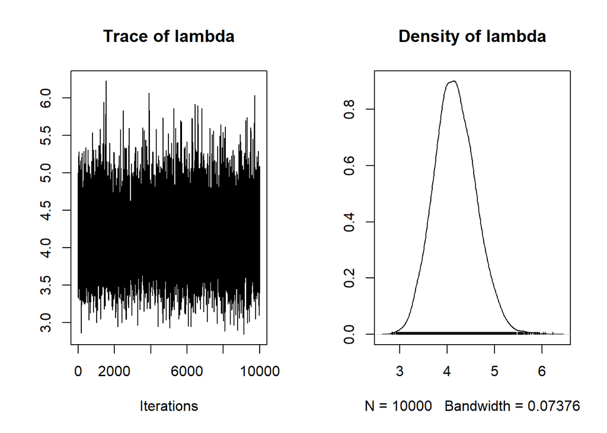

```r
plot(rate_lat_sim)
```

```r
summary(rate_lat_sim)
```

```
##
## Iterations = 1:10000
## Thinning interval = 1
## Number of chains = 1
## Sample size per chain = 10000
##
## 1. Empirical mean and standard deviation for each variable,
##    plus standard error of the mean:
##
##           Mean             SD       Naive SE Time-series SE
##       4.169729       0.439061       0.004391       0.004223
##
## 2. Quantiles for each variable:
##
##  2.5%   25%   50%   75% 97.5%
## 3.357 3.869 4.153 4.459 5.065
```

Based on this model that uses only latitude, we predict there to be about 4.17 large earthquakes per year. This is a quite large prediction in comparison to our other two models. We hypothesize that this is due to the large number of earthquakes that occur in the Aleutian Islands in Alaska, which lie in very restricted range of latitudes. Earthquakes fall on a larger range of longitudes.

```r
# Rjags for rate of large earthquakes


rate_model <- "model{
  #Data
    #Note: dnorm in rjags takes the precision, not st. dev.

  N ~ dpois(mu)
  for (i in 1:length(N)) {
    mu = (sqrt((X[i]+Y[i])^2))*lambda
  }



  #Priors

  lambda ~ dgamma(1,2)

}"

#set up an algorithm to simulate the posterior by
#combining the model (nfl_model) and data (sports)
#set the random number seed
rate_jags <- jags.model(textConnection(rate_model),
                        data = list(N=nrow(quakesAbove7), X=quakesAbove7$longitude, Y=quakesAbove7$latitude),
                        inits = list(.RNG.name = "base::Wichmann-Hill", .RNG.seed = 1989))
#simulate a sample from the posterior
rate_sim <- coda.samples(rate_jags,
                        variable.names = c("lambda"), n.iter=10000)

#store the samples in a data frame:
rate_samples <- data.frame(steps=c(1:10000), rate_sim[[1]])
head(rate_samples)
```

```
##   steps    lambda
## 1     1 0.6663861
## 2     2 0.6803928
## 3     3 0.5930688
## 4     4 0.5173961
## 5     5 0.6643575
## 6     6 0.6023607
```

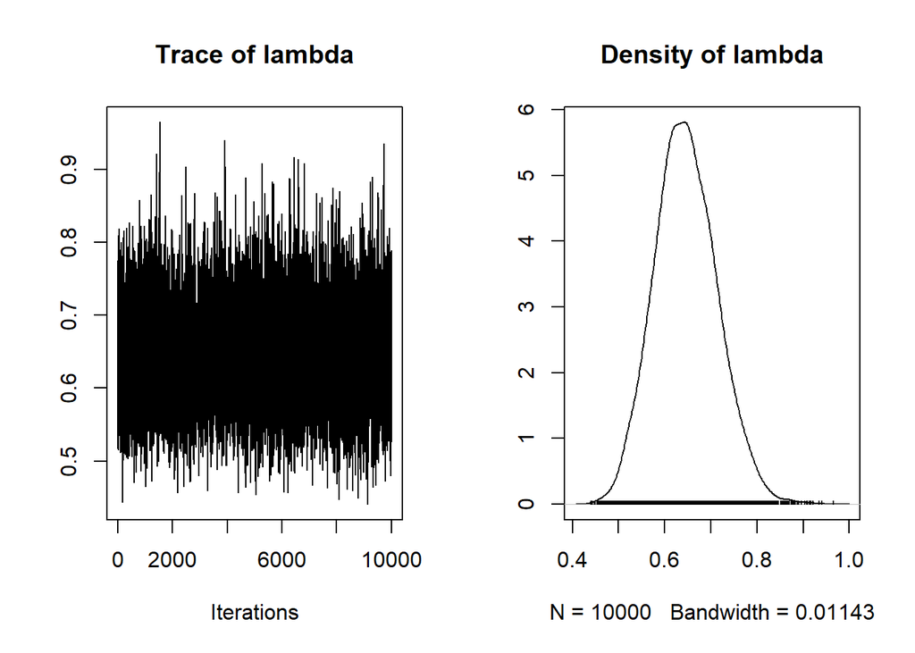

```r
plot(rate_sim)
```

```r
summary(rate_sim)
```

```
##
## Iterations = 1:10000
## Thinning interval = 1
## Number of chains = 1
## Sample size per chain = 10000
##
## 1. Empirical mean and standard deviation for each variable,
##    plus standard error of the mean:
##
##           Mean             SD       Naive SE Time-series SE
##      0.6460673      0.0680292      0.0006803      0.0006543
##
## 2. Quantiles for each variable:
##
##   2.5%    25%    50%    75%  97.5%
## 0.5201 0.5995 0.6435 0.6909 0.7847
```

From this output, we can see that our joint model predicts there to be about 0.65 significant earthquakes per year on average. This leads us to believe that the year 1957, which had 8 significant earthquakes, was an extreme observation. We could further investigate this particular year to try to explain the large number of significant earthquakes. We believe this to be a more accurate model than our previous two, particularly than our model using only latitude.

### Question: How can we predict the magnitude of an earthquake?

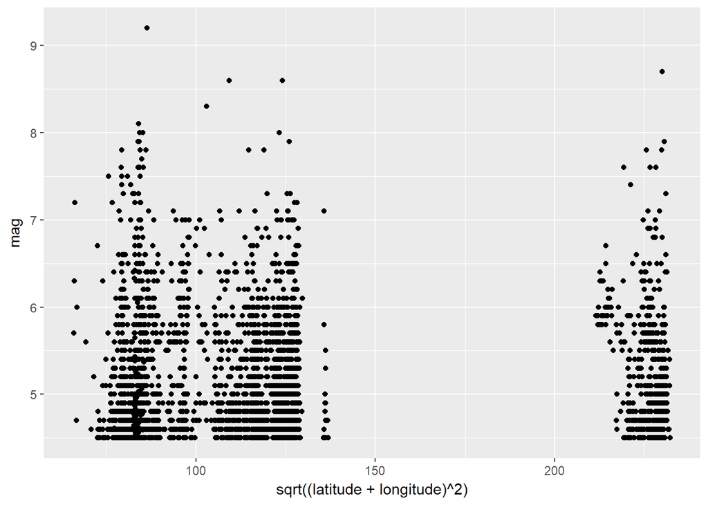

```r
#magnitude by lat/long
ggplot(data=cleanQuakesFin, aes(x=sqrt((latitude + longitude)^2), y=mag)) + geom_point()
```

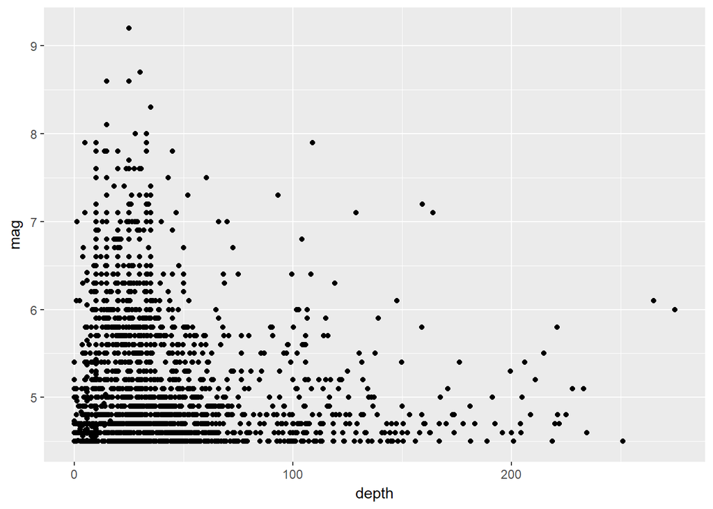

```r
# magnitude by depth
ggplot(data=cleanQuakesFin, aes(x=depth, y=mag)) + geom_point()
```

Notation: $M_i$ = magnitude of earthquake $i$  
$X_i$ = longitude of earthquake $i$  
$Y_i$ = latitude of earthquake $i$  
$d_i$ = depth of earthquake $i$

Models:
Model 1:
$$M_i = \beta_0 + \beta_1X_i+\beta_2Y_i+\epsilon_i$$
$$M_i|\beta_0, \beta_1, \beta_2, \tau \sim N(\beta_0 + \beta_1X_i+\beta_2Y_i, \tau^{-1})$$
$$\beta_k \sim N(0,100^2)$$
$$\tau \sim Gamma(2,2)$$
Model 2:
$$M_i = \beta_0 + \beta_1d_i+\epsilon_i$$
$$M_i|\beta_0, \beta_1, \beta_2, \tau_0, \tau_1 \sim N(\beta_0 + \beta_1d_i, (\tau_0+\tau_1d_i)^{-1})$$
$$\beta_k \sim N(0,100^2)$$
$$\tau_k \sim N(-10,1^2)$$

```r
# Rjags for magnitude by location (lat/long)

mag_loc_model <- "model{
  #Data
  for (i in 1:length(M)) {
    #Note: dnorm in rjags takes the precision, not st. dev.
    M[i] ~ dnorm(beta0+beta1*X[i]+beta2*Y[i], tau)
  }

  #Priors

  beta0 ~ dnorm(0, 1/100^2)
  beta1 ~ dnorm(0, 1/100^2)
  beta2 ~ dnorm(0, 1/100^2)
  tau ~ dgamma(2, 2)

}"

#set up an algorithm to simulate the posterior by
#combining the model (nfl_model) and data (sports)
#set the random number seed
mag_loc_jags <- jags.model(textConnection(mag_loc_model),
                        data = list(M=cleanQuakesFin$mag, X=cleanQuakesFin$longitude, Y=cleanQuakesFin$latitude),
                        inits = list(.RNG.name = "base::Wichmann-Hill", .RNG.seed = 1989))
#simulate a sample from the posterior
mag_loc_sim <- coda.samples(mag_loc_jags,
                        variable.names = c("tau", "beta0", "beta1", "beta2"), n.iter=10000)

#store the samples in a data frame:
mag_loc_samples <- data.frame(steps=c(1:10000), mag_loc_sim[[1]])
head(mag_loc_samples)
```

```
##   steps    beta0        beta1         beta2      tau
## 1     1 5.134637 0.0001687925  8.248685e-05 2.122951
## 2     2 5.150673 0.0001385227 -7.398305e-05 2.250025
## 3     3 5.147919 0.0001801706 -1.408598e-04 2.130700
## 4     4 5.150605 0.0001582072 -4.721057e-05 2.226120
## 5     5 5.127133 0.0001130093  2.856898e-04 2.180760
## 6     6 5.149614 0.0002507300  4.793221e-04 2.119616
```

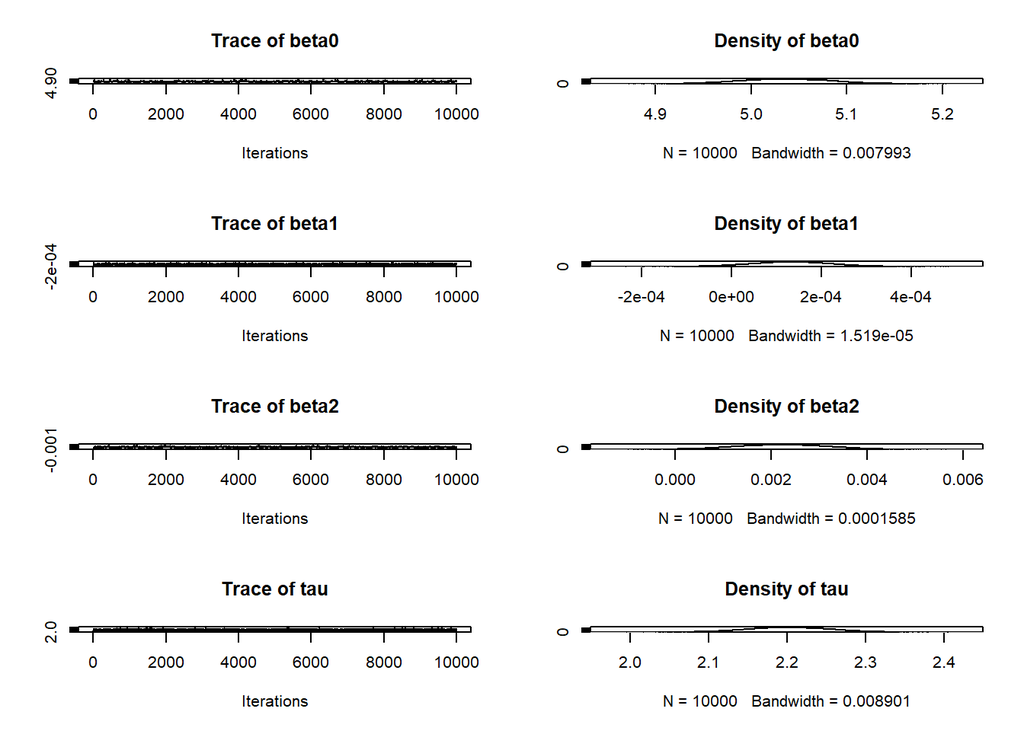

```r
plot(mag_loc_sim)
```

```r
summary(mag_loc_sim)
```

```
##
## Iterations = 1:10000
## Thinning interval = 1
## Number of chains = 1
## Sample size per chain = 10000
##
## 1. Empirical mean and standard deviation for each variable,
##    plus standard error of the mean:
##
##            Mean        SD  Naive SE Time-series SE
## beta0 5.0359509 0.0475778 4.758e-04      2.671e-03
## beta1 0.0001305 0.0000910 9.100e-07      1.464e-06
## beta2 0.0022061 0.0009436 9.436e-06      5.260e-05
## tau   2.2021931 0.0529833 5.298e-04      5.449e-04
##
## 2. Quantiles for each variable:
##
##             2.5%       25%       50%       75%    97.5%
## beta0  4.945e+00 5.003e+00 5.0354772 5.0689128 5.131440
## beta1 -4.922e-05 6.991e-05 0.0001307 0.0001911 0.000310
## beta2  3.372e-04 1.560e-03 0.0022059 0.0028595 0.004011
## tau    2.098e+00 2.166e+00 2.2017647 2.2386614 2.305810
```

What we believe this model is telling us is that the expected magnitude of an earthquake is a 5.04, with very little influence from either latitude or longitude.

```r
# Rjags for magnitude by depth

depthAbove1Quakes <- filter(cleanQuakesFin, depth > 1) # this helped with earthquakes on the surface with tiny depth

mag_dep_model <- "model{
  #Data
  for (i in 1:length(M)) {
    #Note: dnorm in rjags takes the precision, not st. dev.
    M[i] ~ dnorm(beta0+beta1*d[i], tau0 + sqrt((tau1)^2)*d[i])
  }

  #Priors

  beta0 ~ dnorm(0, 1/100^2)
  beta1 ~ dnorm(0, 1/100^2)
  tau0 ~ dnorm(-10, 1)
  tau1 ~ dnorm(-10, 1)

}"

#set up an algorithm to simulate the posterior by
#combining the model (nfl_model) and data (sports)
#set the random number seed
mag_dep_jags <- jags.model(textConnection(mag_dep_model),
                        data = list(M=depthAbove1Quakes$mag, d=(depthAbove1Quakes$depth)),
                        inits = list(.RNG.name = "base::Wichmann-Hill", .RNG.seed = 1989))
#simulate a sample from the posterior
mag_dep_sim <- coda.samples(mag_dep_jags,
                        variable.names = c("tau0", "tau1", "beta0", "beta1"), n.iter=10000)

#store the samples in a data frame:
mag_dep_samples <- data.frame(steps=c(1:10000), mag_dep_sim[[1]])
head(mag_dep_samples)
```

```
##   steps    beta0        beta1      tau0      tau1
## 1     1 5.156251 -0.001333749 -10.19789 -9.271356
## 2     2 5.158046 -0.001340929 -10.19629 -9.270812
## 3     3 5.157983 -0.001343544 -10.19476 -9.268259
## 4     4 5.158677 -0.001341236 -10.19349 -9.267016
## 5     5 5.157814 -0.001344584 -10.19146 -9.267032
## 6     6 5.155702 -0.001324485 -10.19222 -9.266721
```

```r
summary(mag_dep_sim)
```

```
##
## Iterations = 1001:11000
## Thinning interval = 1
## Number of chains = 1
## Sample size per chain = 10000
##
## 1. Empirical mean and standard deviation for each variable,
##    plus standard error of the mean:
##
##            Mean        SD  Naive SE Time-series SE
## beta0  5.156199 1.893e-03 1.893e-05      3.934e-05
## beta1 -0.001323 2.252e-05 2.252e-07      4.635e-07
## tau0  -7.103376 1.771e+00 1.771e-02      1.428e+00
## tau1  -6.458568 1.610e+00 1.610e-02      1.298e+00
##
## 2. Quantiles for each variable:
##
##             2.5%       25%       50%       75%     97.5%
## beta0   5.152485  5.154930  5.156187  5.157465  5.160000
## beta1  -0.001367 -0.001338 -0.001323 -0.001308 -0.001279
## tau0  -10.035133 -8.637676 -7.123036 -5.585739 -4.160858
## tau1   -9.124465 -7.852729 -6.476620 -5.078281 -3.783275
```

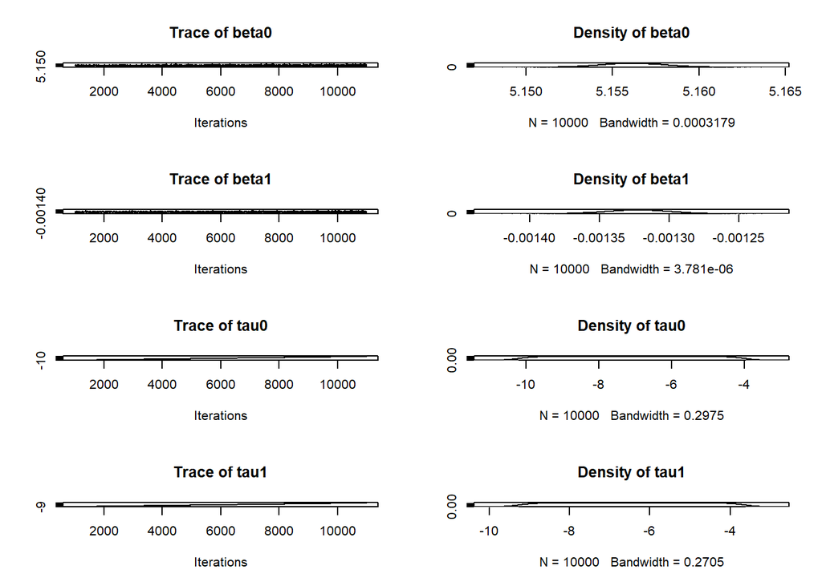

```r
plot(mag_dep_sim)
```

This model predicts a slightly higher average magnitude of 5.15, with large variance and a slight negative correlation between depth and magnitude.